# Regression

Cameron Jones

Stat 240: Summer 2023

*Disclaimer: This material was presented briefly at in-person discussions as a brief recap of the week’s concepts during the Spring ’23 iteration of Stat 240. It is not a comprehensive list on everything you need to know for this topic.*

# Concept Review

##### Data: Star Wars Characters

We are interested in predicting the mass (kg) of the star wars characters using their height (cm). Note that these are two continuous numeric outcomes; other types of variables have analogous forms of regression covered in other classes (or come talk to me!)

```r
head(starwars[,c("name", "height", "mass")])
```

```
## # A tibble: 6 × 3
##   name           height  mass
##   <chr>           <int> <dbl>
## 1 Luke Skywalker    172    77
## 2 C-3PO             167    75
## 3 R2-D2              96    32
## 4 Darth Vader       202   136
## 5 Leia Organa       150    49
## 6 Owen Lars         178   120
```

[figure not shown]

```r
# geom_text_repel is a "smart" point labeler from the ggrepel library

ggplot(starwars, aes(x = height, y = mass, label = name)) + geom_point() + geom_text_repel()
```

### Linear Regression

**Model**

$$Y_i = \beta_0 + \beta_1 *X_i + \epsilon_i$$

*Key assumptions*

- We assume that $Y_i$ is a LINEAR function of $X_i$ rather than some polynomial fit.
- We assume that $\epsilon_i$’s are independent. One character’s deviation from the line doesn’t affect another’s.
- We assume that $\epsilon_i$’s follow the $Normal(0, \sigma^2)$ distribution. The zero represents the fact that on average, heights are generated right on the best fit line. We do not know the true variance $\sigma^2$, but crucially it is constant and does not vary with $X$.

**Hypotheses**

$$H_0: \beta_1 = 0$$

$$H_A: \beta_1 \neq 0$$

**Inference**

Using theory, inference on $\beta_1$ is more involved and is gone over in detail in lecture. However, the framework is similar to the t-test in that under the null hypothesis, the estimated $\hat{\beta_1}/SE(\hat{\beta_1})$ should follow a $t(n-2)$ distribution, and p-values are calculated from this fact.

The command `lm(outcome ~ input1 + input2 + ..., data)` does all this for you, and inference results can be extracted by running `summary()` on the model object.

```r
model = lm(mass ~ height, starwars)

# running just summary(model) gives you a ton of information, I reduce it to just the relevant info with $coefficients
summary(model)$coefficients
```

```
##               Estimate  Std. Error    t value  Pr(>|t|)
## (Intercept) -13.810314 111.1545260 -0.1242443 0.9015590
## height        0.638571   0.6260583  1.0199865 0.3120447
```

```r
# The algebraic forms of these values are covered in lecture, they are complex
estimate = 0.638571
se = 0.6260583
n = 59 # you can check this with starwars %>% drop_na(height, mass) %>% count()

# But, using them, we can recreate the t-value and p-value from lm
(t_value = estimate/se)
```

```
## [1] 1.019986
```

```r
(p_value = 2*(1-pt(t_value, df = n-2)))
```

```
## [1] 0.3120447
```

The p-value of this test is 0.312. We fail to find evidence that the height of Star Wars characters is related to their mass.

This should make you go… really?

### Outliers and Their Importance

Remember the scatter plot at the beginning of this file? Jabba the Hutt, a large outlier, has an extreme effect on our linear model!

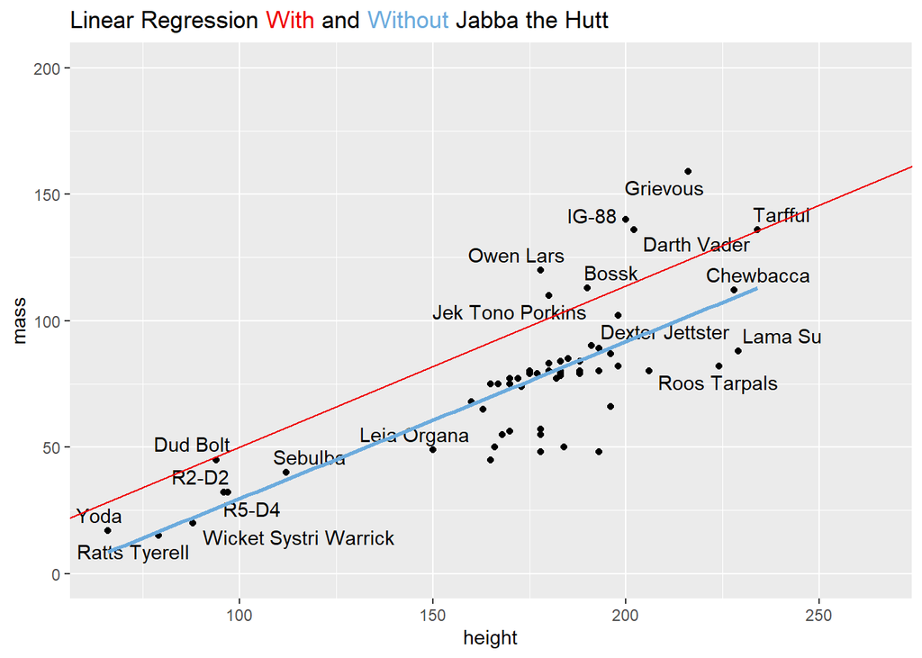

Re-running the linear model without Jabba the Hutt,

```r
summary(lm(mass ~ height, starwars %>% filter(!str_detect(name, "Jabba"))))$coefficients
```

```
##                Estimate  Std. Error   t value     Pr(>|t|)
## (Intercept) -32.5407582 12.56052521 -2.590716 1.218820e-02
## height        0.6213599  0.07072758  8.785255 4.017933e-12
```